# Wrangling the 2026 Winter Olympics Data

Mirada Makhmutova

03/21/2026

# Introduction part!

The Winter Olympics bring together various sports, venues, and events across a packed schedule. While the raw schedule data is informative, it is not immediately structured for answering deeper questions.

In this tutorial, we will walk through how to wrangle and transform a real-world dataset to uncover insights about:

- Which sports dominate the Olympic schedule?
- Which venues host the most events?
- How long different events typically last?

# Dataset

We will use the 2026 Winter Olympics schedule dataset, provided by the TidyTuesday project (and their suggested questoins as well). You should install tidytuesdayR package and load following R Packages below: [Source](https://github.com/rfordatascience/tidytuesday/blob/main/data/2026/2026-02-10/readme.md#schedulecsv)

```r
# Load any R Packages you may need
library(tidyverse)
## install.packages("tidytuesdayR")
schedule <- readr::read_csv('https://raw.githubusercontent.com/rfordatascience/tidytuesday/main/data/2026/2026-02-10/schedule.csv')
```

This dataset includes information about event timing, disciplines, venues, and whether events are training sessions or medal competitions

# **Let’s start now!**

## **Step 1:** clean data to include only real competition events

```r
events <- schedule %>%
  filter(is_training == FALSE)
```

# **Which sports dominate the Olympic schedule?**

To examine that we will look to which sports have the most events. Let’s count the number of events per sport:

```r
discipline_counts <- events %>%
  count(discipline_name, sort = TRUE)

discipline_counts
```

```
## # A tibble: 16 × 2
##    discipline_name               n
##    <chr>                     <int>
##  1 Curling                     436
##  2 Freestyle Skiing            222
##  3 Snowboard                   192
##  4 Ice Hockey                  173
##  5 Short Track Speed Skating   114
##  6 Speed Skating                78
##  7 Cross-Country Skiing         59
##  8 Ski Jumping                  57
##  9 Alpine Skiing                48
## 10 Figure Skating               48
## 11 Bobsleigh                    46
## 12 Luge                         39
## 13 Biathlon                     33
## 14 Nordic Combined              27
## 15 Skeleton                     27
## 16 Ski Mountaineering           21
```

This plot shows that sports such as Curling, Freestyle Skiing and Snowboard have the highest number of scheduled events.

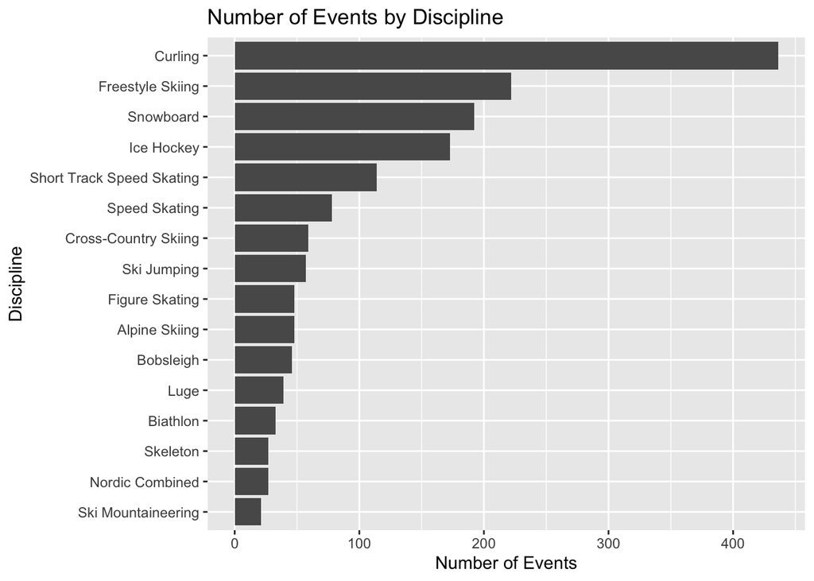

```r
ggplot(discipline_counts, aes(x = reorder(discipline_name, n), y = n)) +
  geom_col() +
  coord_flip() +
  labs(
    title = "Number of Events by Discipline",
    x = "Discipline",
    y = "Number of Events"
  )
```

# **Which Venues Host the Most Events?**

To determine which venues host the most events, we count occurrences of venue_name; however, since the data contains missing values, we first apply mode imputation by replacing them with the most frequent venue to ensure all events are included in the analysis.

```r
#Finding mode (most common value for venue_name):
mode_venue <- events %>%
  filter(!is.na(venue_name)) %>%
  count(venue_name, sort = TRUE) %>%
  slice(1) %>%
  pull(venue_name)
mode_venue
```

```
## [1] "Cortina Curling Olympic Stadium"
```

```r
#Impute missing values with mode
events_imputed <- events %>%
  mutate(
    venue_name = if_else(is.na(venue_name), mode_venue, venue_name)
  )
# Count venues
venue_counts <- events_imputed %>%
  count(venue_name, sort = TRUE)

venue_counts
```

```
## # A tibble: 13 × 2
##    venue_name                              n
##    <chr>                               <int>
##  1 Cortina Curling Olympic Stadium       493
##  2 Livigno Snow Park                     297
##  3 Milano Ice Skating Arena              162
##  4 Cortina Sliding Centre                112
##  5 Milano Santagiulia Ice Hockey Arena    88
##  6 Livigno Aerials & Moguls Park          83
##  7 Milano Speed Skating Stadium           78
##  8 Milano Rho Ice Hockey Arena            71
##  9 Predazzo Ski Jumping Stadium           70
## 10 Tesero Cross-Country Skiing Stadium    68
## 11 Stelvio Ski Centre                     46
## 12 Anterselva Biathlon Arena              33
## 13 Tofane Alpine Skiing Centre            19
```

Some venues host significantly more events than others, likely due to multi-use facilities or sports with many sub-events. Let’s visualise it:

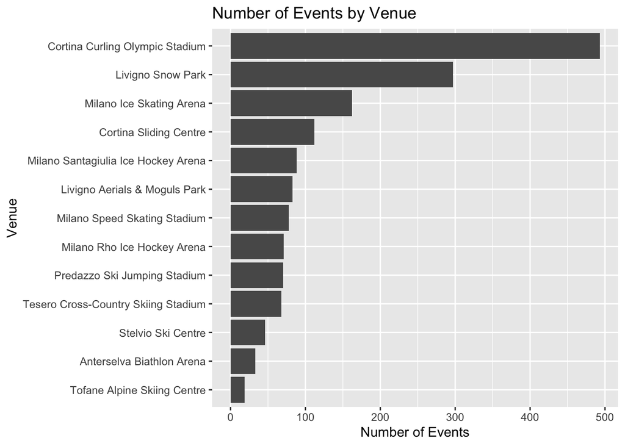

```r
ggplot(venue_counts, aes(x = reorder(venue_name, n), y = n)) +
  geom_col() +
  coord_flip() +
  labs(
    title = "Number of Events by Venue",
    x = "Venue",
    y = "Number of Events"
  )
```

# **How long different events typically last**

To calculate duration we will use start and end times that dataset provides and then compute it using mutate()

```r
events <- events %>%
  mutate(duration_minutes = as.numeric(
    difftime(end_datetime_local, start_datetime_local, units = "mins")
  ))
```

## **More advanced**

Now let’s:

- Calculate overall average duration:
- Summarize the average duration of events for each discipline and add new column that shows if its event’s average duration is higher than average duration of all events:

```r
overall_avg <- mean(events$duration_minutes, na.rm = TRUE)

duration_summary <- events %>%
  group_by(discipline_name) %>%
  summarize(
    avg_duration = mean(duration_minutes, na.rm = TRUE)) %>%
  mutate(
    above_average = avg_duration > overall_avg
  )
duration_summary
```

```
## # A tibble: 16 × 3
##    discipline_name           avg_duration above_average
##    <chr>                            <dbl> <lgl>
##  1 Alpine Skiing                    103.  TRUE
##  2 Biathlon                          68.6 FALSE
##  3 Bobsleigh                         56.0 FALSE
##  4 Cross-Country Skiing              57.9 FALSE
##  5 Curling                          160.  TRUE
##  6 Figure Skating                   143.  TRUE
##  7 Freestyle Skiing                  29.1 FALSE
##  8 Ice Hockey                       150   TRUE
##  9 Luge                              39.9 FALSE
## 10 Nordic Combined                   34.9 FALSE
## 11 Short Track Speed Skating         12.6 FALSE
## 12 Skeleton                          58.5 FALSE
## 13 Ski Jumping                       41.7 FALSE
## 14 Ski Mountaineering                19.3 FALSE
## 15 Snowboard                         26.4 FALSE
## 16 Speed Skating                     37.4 FALSE
```

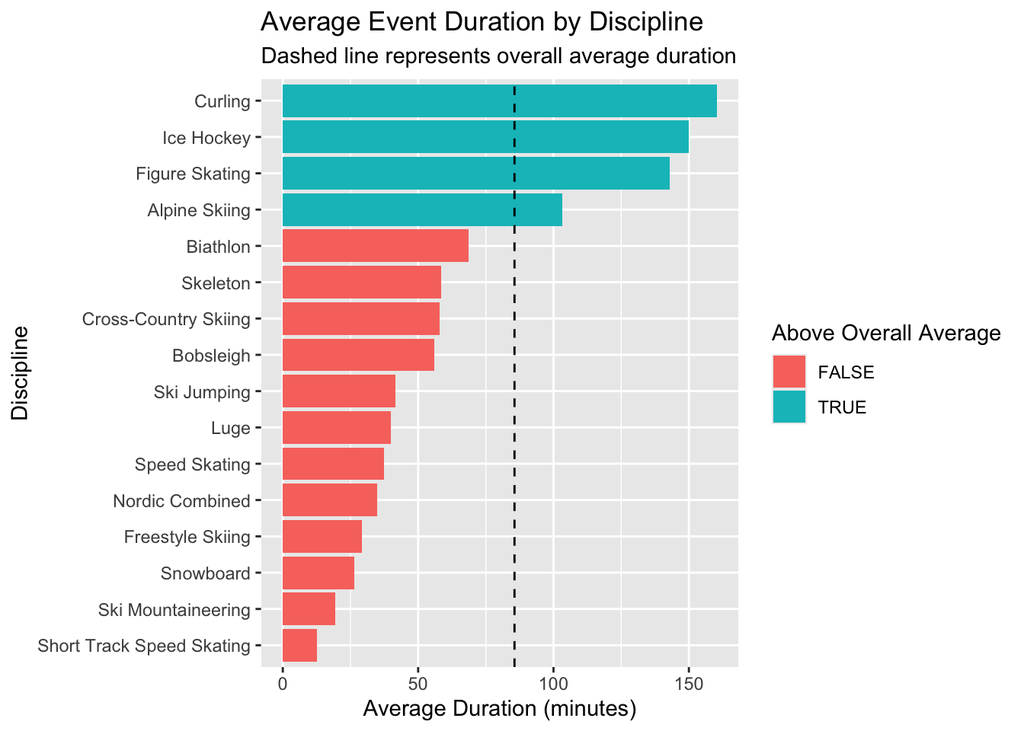

```r
ggplot(duration_summary, aes(
  x = reorder(discipline_name, avg_duration),
  y = avg_duration,
  fill = above_average
)) +
  geom_col() +
  coord_flip() +
  geom_hline(yintercept = overall_avg, linetype = "dashed") +
  labs(
    title = "Average Event Duration by Discipline",
    subtitle = "Dashed line represents overall average duration",
    x = "Discipline",
    y = "Average Duration (minutes)",
    fill = "Above Overall Average"
  )
```

From the visualization, we observe that disciplines such as Curling, Ice Hockey, and Figure Skating have significantly longer event durations than the overall average. In contrast, most disciplines fall below the average, with events like Short Track Speed Skating and Ski Mountaineering.

# **References**

- **TidyTuesday (2026). 2026 Winter Olympics Schedule Dataset. Retrieved from:** [2026 Winter Olympics Schedule Dataset](https://raw.githubusercontent.com/rfordatascience/tidytuesday/main/data/2026/2026-02-10/schedule.csv)
- **ggplot2 Documentation - Reference Lines** [Reference Line](https://ggplot2.tidyverse.org/reference/geom_abline.html)
- **ggplot2 Documentation – coord_flip** [coord_flip](https://ggplot2.tidyverse.org/reference/coord_flip.html)
- **difftime: Time Intervals / Differences** [source](https://www.rdocumentation.org/packages/base/versions/3.6.2/topics/difftime)